# Random Samples, Central Limit Theorem, and Estimators

Kaleb Afework and Chantoan ha

In this project, we will work with the sampling distributions of statistics, the Central Limit Theorem (CLT), and properties of estimators.

The Central Limit Theorem and the properties of estimators are one of the most powerful concepts/tools that we learn in this course. It will send you back to the beginning of this class, require you to remind yourself and use the distributions and probability principles that we studied then, and yet at the end of this class now, it will set the stage for new beginnings for many things to come. Make sure to have fun, and good luck!

# 1 Random Samples

## 1.1 Normal Distibution

Consider the Normal distribution $N(\mu = 5, \sigma = 1.2)$. We will get random samples from this distribution and check out the histograms for each of these samples. We expect that as the sample size increases, the sample distribution will provide an increasingly improved approximation of the the true distribution.

### 1.1.1 Density of $N(\mu, \sigma)$.

Plot the density curve of $N(\mu, \sigma)$,

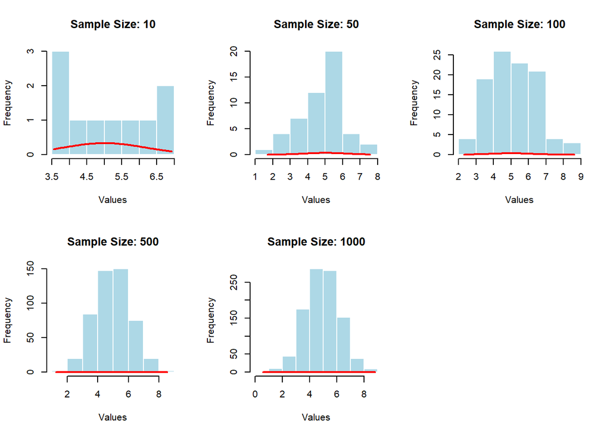

```r
mu <- 5
sigma <- 1.2

sample_sizes <- c(10, 50, 100, 500, 1000)

par(mfrow = c(2, 3))

for (i in 1:length(sample_sizes)) {
  sample_size <- sample_sizes[i]

  sample <- rnorm(sample_size, mean = mu, sd = sigma)

  hist(sample, main = paste("Sample Size:", sample_size),
       xlab = "Values", ylab = "Frequency", col = "lightblue", border = "white")

  x <- seq(min(sample), max(sample), length.out = 100)
  y <- dnorm(x, mean = mu, sd = sigma)
  lines(x, y, col = "red", lwd = 2)
}

par(mfrow = c(1, 1))
```

### 1.1.2 Sample distributions

For the sample sizes $4, 7, 10, 15, 20, 30, 40, 80, 1000$ get random samples of respective size, and plot the histograms for each of these samples.

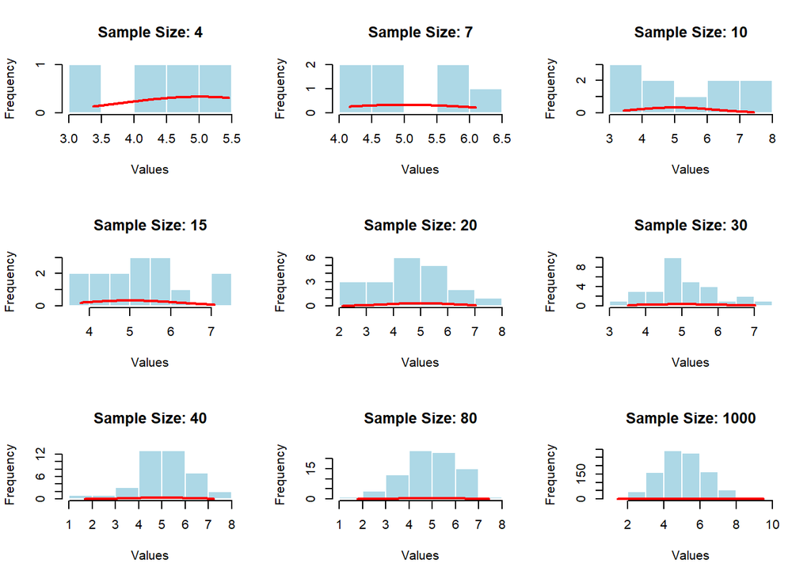

```r
mu <- 5
sigma <- 1.2

sample_sizes <- c(4, 7, 10, 15, 20, 30, 40, 80, 1000)

par(mfrow = c(3, 3))

for (i in 1:length(sample_sizes)) {
  sample_size <- sample_sizes[i]

  sample <- rnorm(sample_size, mean = mu, sd = sigma)

  hist(sample, main = paste("Sample Size:", sample_size),
       xlab = "Values", ylab = "Frequency", col = "lightblue", border = "white")

  x <- seq(min(sample), max(sample), length.out = 100)
  y <- dnorm(x, mean = mu, sd = sigma)
  lines(x, y, col = "red", lwd = 2)
}
```

```r
par(mfrow = c(1, 1))
```

What do you notice?

Looking at the red lines, though the bar graphs are different, they look generally the same due to the distribution of the bar graph.

## 1.2 Gamma Distribution

Consider the Gamma distribution $\text{Gamma}(\alpha = 2, \beta = 1.5)$. We will get random samples from this distribution and check out the histograms for each of these samples. We expect that as the sample size increases, the sample distribution will provide an increasingly improved approximation of the the true distribution.

### 1.2.1 Density of $\text{Gamma}(\alpha = 2, \beta = 1.5)$.

Plot the density curve of $\text{Gamma}(\alpha = 2, \beta = 1.5)$,

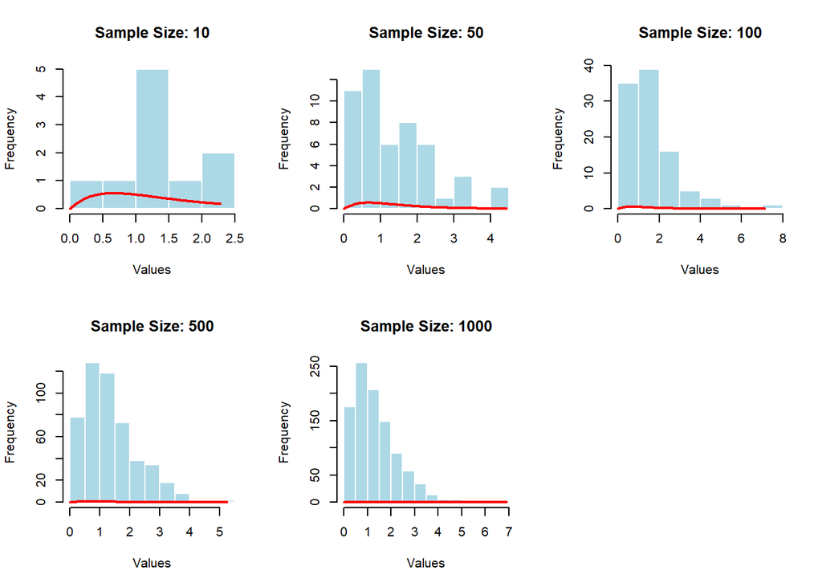

```r
alpha <- 2
beta <- 1.5

sample_sizes <- c(10, 50, 100, 500, 1000)

par(mfrow = c(2, 3))

for (i in 1:length(sample_sizes)) {
  sample_size <- sample_sizes[i]

  sample <- rgamma(sample_size, shape = alpha, rate = beta)

  hist(sample, main = paste("Sample Size:", sample_size),
       xlab = "Values", ylab = "Frequency", col = "lightblue", border = "white")

  x <- seq(0, max(sample), length.out = 100)
  y <- dgamma(x, shape = alpha, rate = beta)
  lines(x, y, col = "red", lwd = 2)
}

par(mfrow = c(1, 1))
```

### 1.2.2 Sample distributions

For the sample sizes $4, 7, 10, 15, 20, 30, 40, 80, 1000$ get random samples of respective size, and plot the histograms for each of these samples.

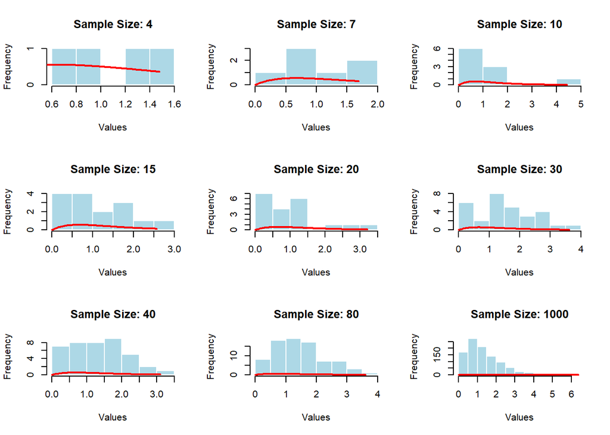

```r
alpha <- 2
beta <- 1.5

sample_sizes <- c(4, 7, 10, 15, 20, 30, 40, 80, 1000)

par(mfrow = c(3, 3))

for (i in 1:length(sample_sizes)) {
  sample_size <- sample_sizes[i]


  sample <- rgamma(sample_size, shape = alpha, rate = beta)

  hist(sample, main = paste("Sample Size:", sample_size),
       xlab = "Values", ylab = "Frequency", col = "lightblue", border = "white")

  x <- seq(0, max(sample), length.out = 100)
  y <- dgamma(x, shape = alpha, rate = beta)
  lines(x, y, col = "red", lwd = 2)
}
```

```r
par(mfrow = c(1, 1))
```

What do you notice? As you add more samples to the graphs, the line gets more straight and more uniform due to the CLT where more samples creates a more uniform graph.

# 2 Sampling Distribution of Sample Max

## 2.1 Discrete Uniform distribution

Suppose we are working with the discrete uniform random variable taking values $\{1, 2, 3, 4, 5, 6\}$.

Define a function “disc_samp” that takes input “n” and returns a random sample of size “n” from this distribution.

```r
disc_samp <- function(n) {
  sample <- sample(1:6, n, replace = TRUE)
  return(sample)
}


sample_size <- 10
random_sample <- disc_samp(sample_size)
print(random_sample)
```

```
##  [1] 5 3 3 2 1 4 6 2 3 5
```

Use the “disc_samp” function and the replicate function to to get the histograms for the sampling distribution of the sample max when working with sample sizes $n = 1, 2, 3, 4,5 15$. Be sure to have appropriate titles for your histograms.

```r
library(ggplot2)

disc_samp <- function(n) {
  sample <- sample(1:6, n, replace = TRUE)
  return(sample)
}
```

Use the “disc_samp” function and the replicate function to to get the histograms for the sampling distribution of the sample max when working with sample sizes $n = 1, 2, 3, 4,5 15$. Be sure to have appropriate titles for your histograms.

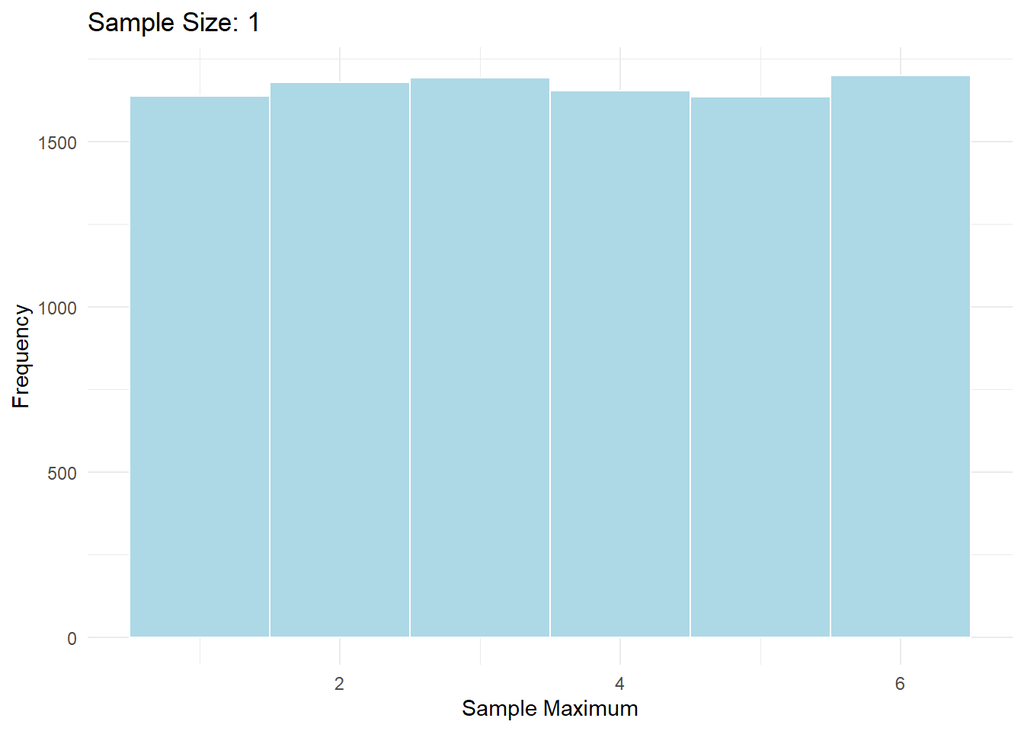

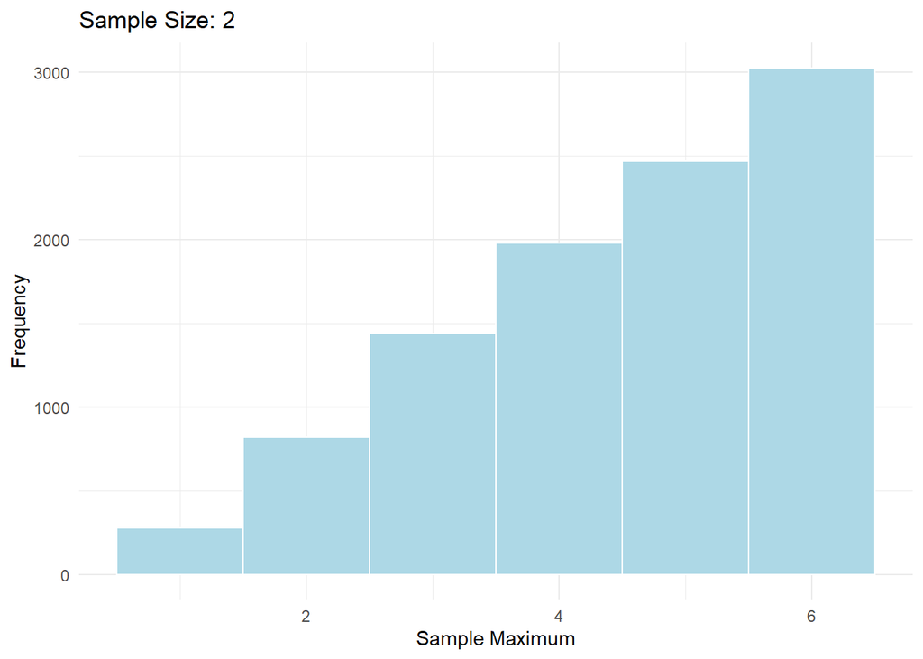

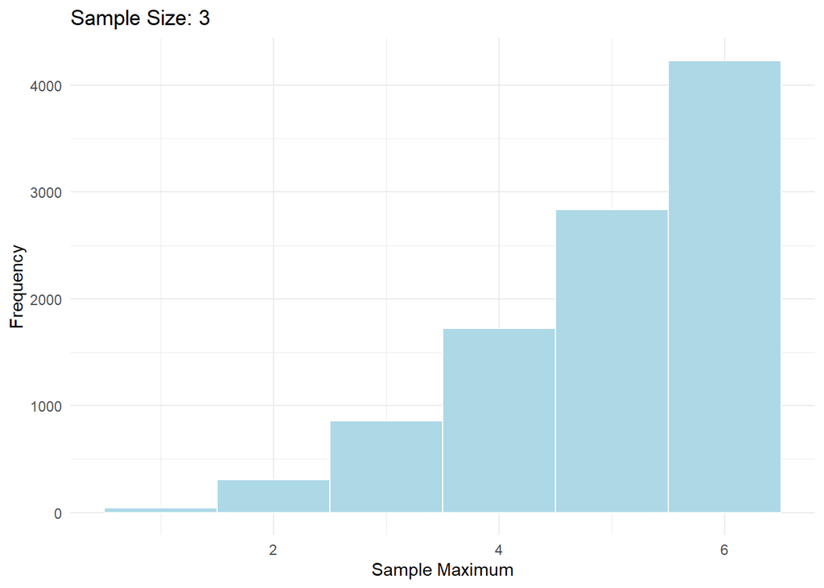

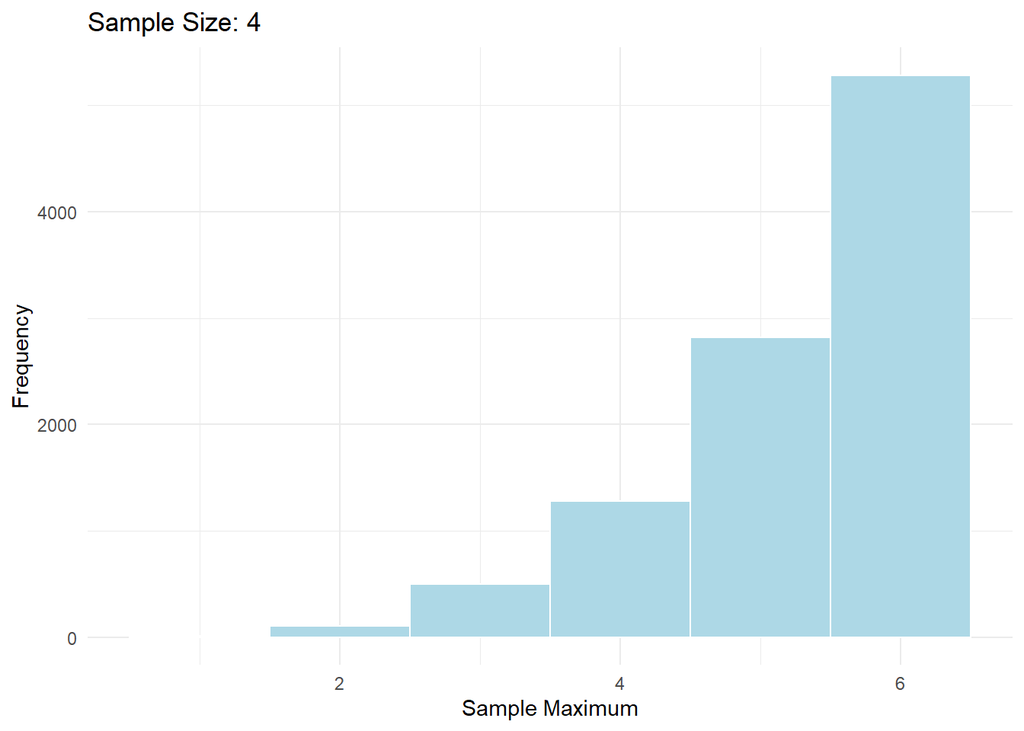

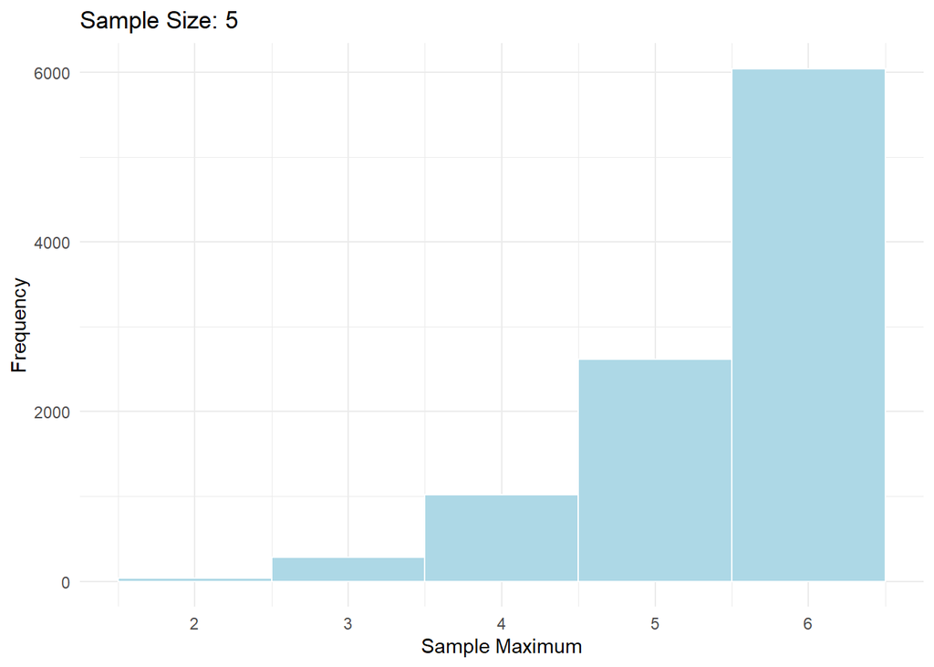

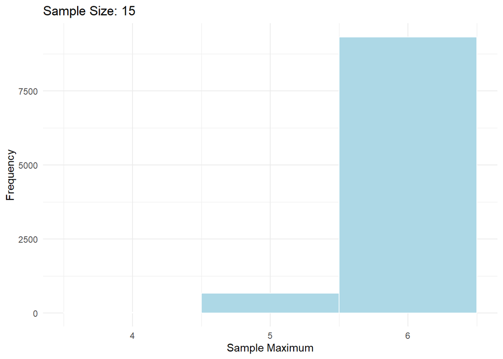

```r
sample_sizes <- c(1, 2, 3, 4, 5, 15)

for (i in 1:length(sample_sizes)) {
  sample_size <- sample_sizes[i]

  samples <- replicate(10000, max(disc_samp(sample_size)))

  p <- ggplot(data.frame(samples), aes(x = samples)) +
    geom_histogram(binwidth = 1, fill = "lightblue", color = "white") +
    labs(title = paste("Sample Size:", sample_size),
         x = "Sample Maximum", y = "Frequency") +
    theme_minimal()

  print(p)
}
```

WHAT DO YOU NOTICE The samples get more skewed as you add more samples.

## 2.2 A Skewed Discrete Distribution

Suppose we are working with the discrete random variable taking values $\{1, 2, 3, 4, 5, 6\}$ and having the following probability mass function:

$$p(1) = 0.5, \quad p(2) = p(3) = \cdots = p(6) =
0.1$$

Define a function “disc_samp_1” that takes input “n” and returns a random sample of size “n” from this distribution.

```r
disc_samp_1 <- function(n) {
  values <- c(1, 2, 3, 4, 5, 6)
  probabilities <- c(0.5, 0.1, 0.1, 0.1, 0.1, 0.1)

  sample <- sample(values, n, replace = TRUE, prob = probabilities)

  return(sample)
}

sample_size <- 10
random_sample <- disc_samp_1(sample_size)
print(random_sample)
```

```
##  [1] 6 1 5 1 4 1 2 1 1 5
```

Use the “disc_samp_1” function and the replicate function to to get the histograms for the sampling distribution of the sample max when working with sample sizes $n = 1, 2, 3, 4,5 15$. Be sure to have appropriate titles for your histograms.

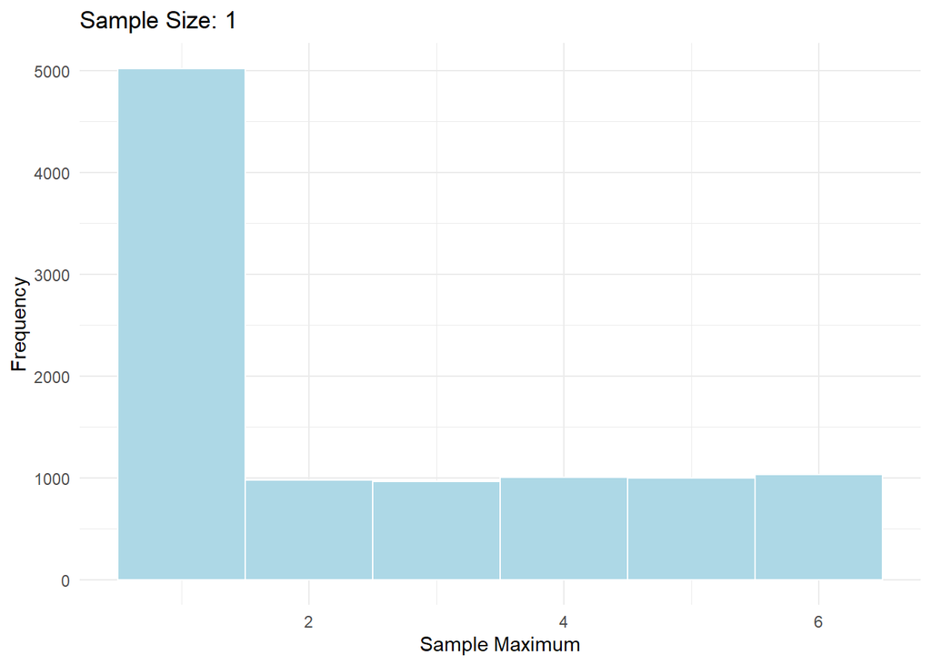

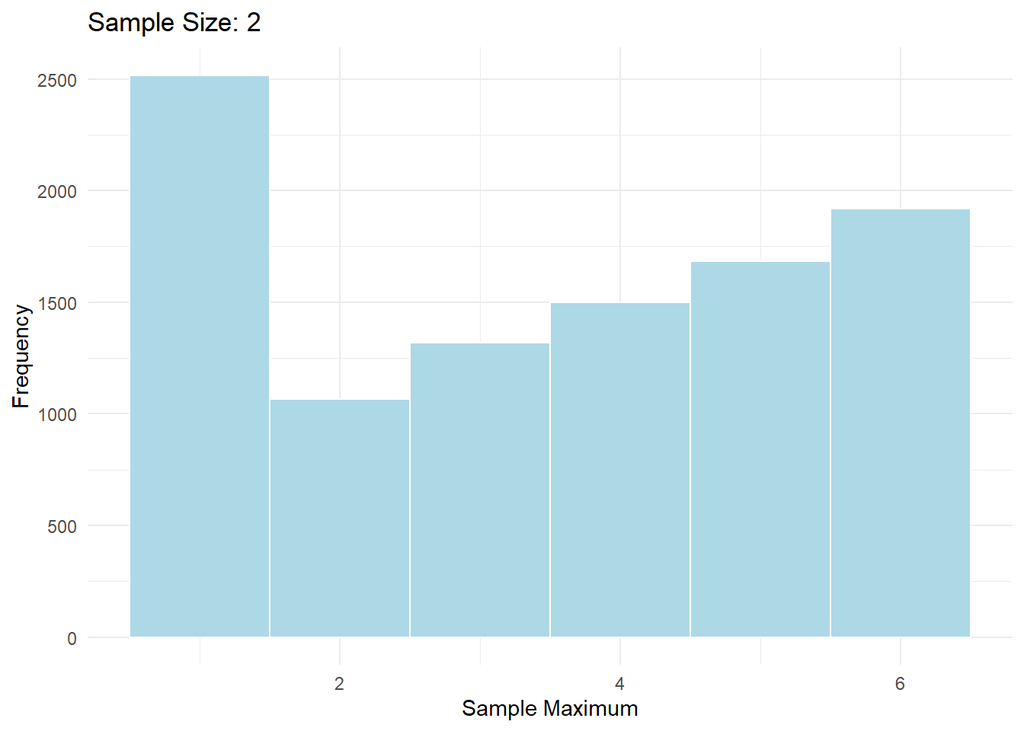

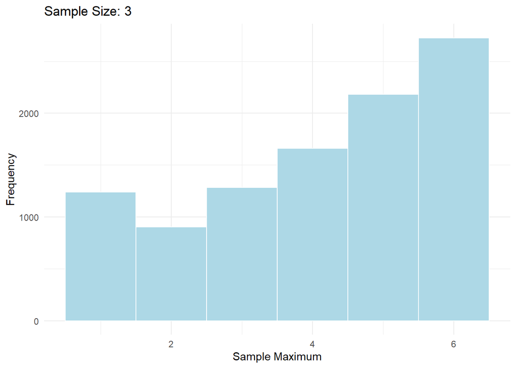

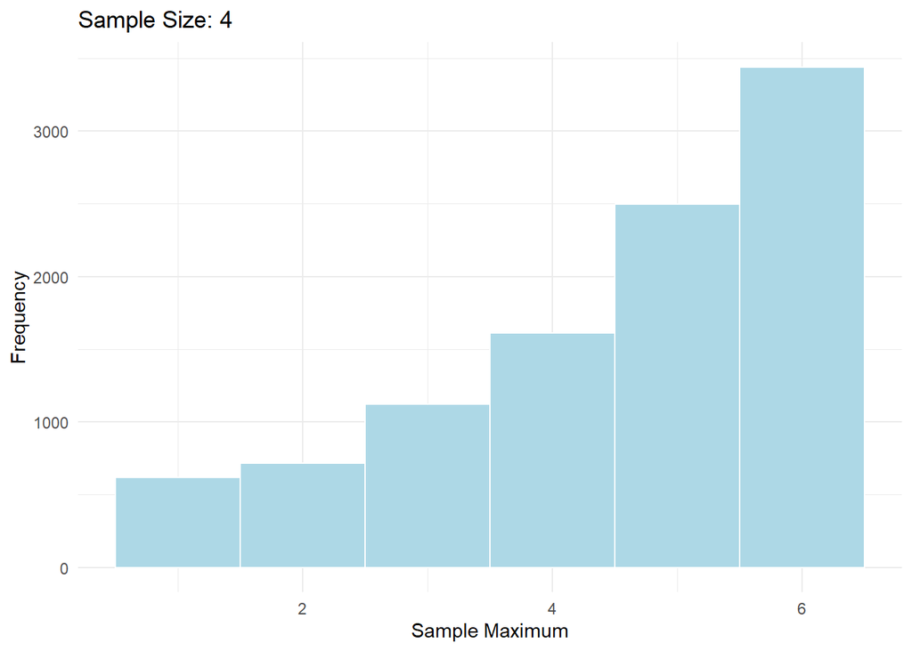

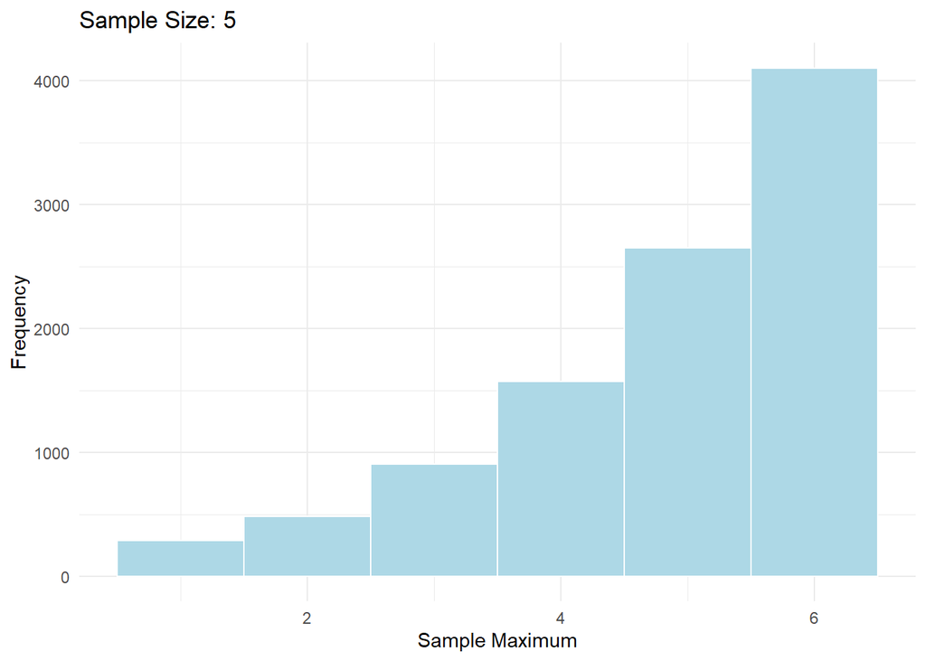

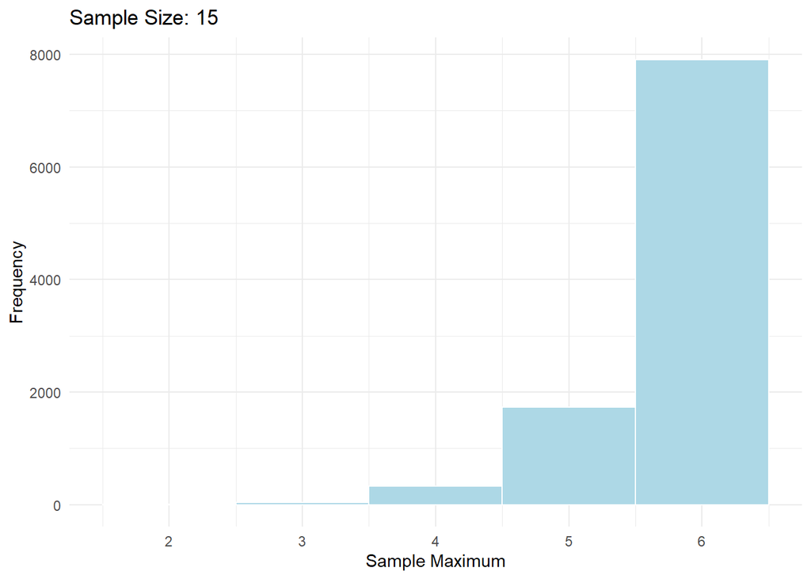

```r
library(ggplot2)

disc_samp_1 <- function(n) {
  values <- c(1, 2, 3, 4, 5, 6)
  probabilities <- c(0.5, 0.1, 0.1, 0.1, 0.1, 0.1)

  sample <- sample(values, n, replace = TRUE, prob = probabilities)

  return(sample)
}

sample_sizes <- c(1, 2, 3, 4, 5, 15)

for (i in 1:length(sample_sizes)) {
  sample_size <- sample_sizes[i]

  samples <- replicate(10000, max(disc_samp_1(sample_size)))

  p <- ggplot(data.frame(samples), aes(x = samples)) +
    geom_histogram(binwidth = 1, fill = "lightblue", color = "white") +
    labs(title = paste("Sample Size:", sample_size),
         x = "Sample Maximum", y = "Frequency") +
    theme_minimal()

  print(p)
}
```

WHAT DO YOU NOTICE It starts off being skewed to the right but adding more samples makes the graph skew more to the left.

# 3 Central Limit Theorem

## 3.1 Exponential Distribution

Use the replicate function to get the histograms for the sampling distribution of the sample mean when working with sample sizes $n = 1, 2, 3, 4, 15, 500$. Be sure to have appropriate titles for your histograms.

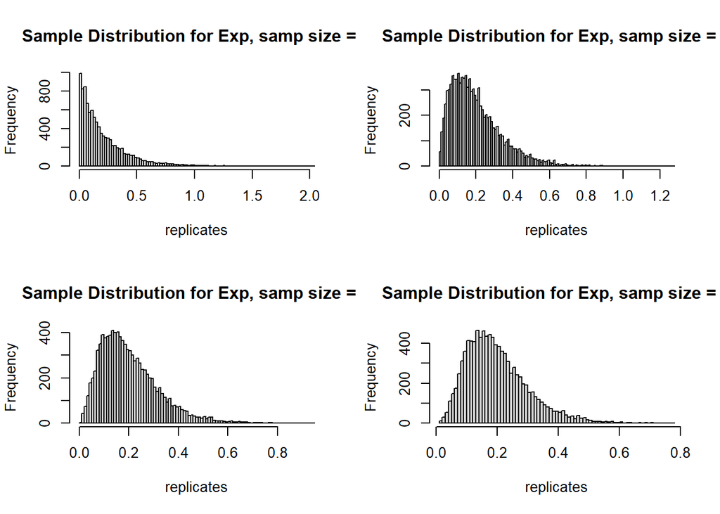

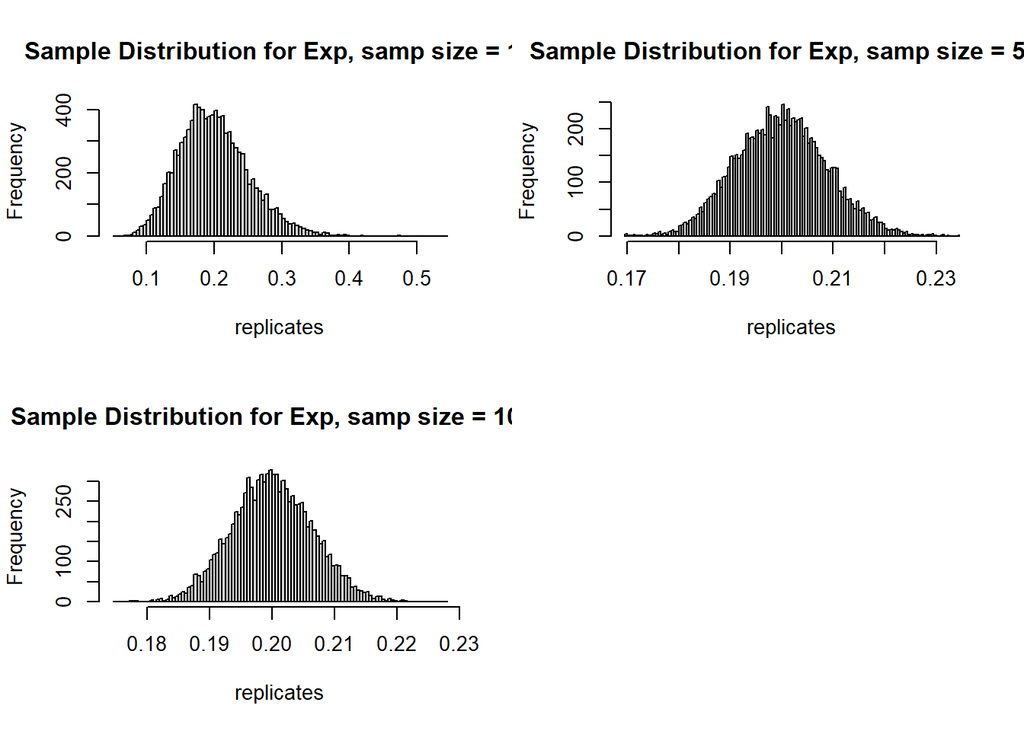

```r
sample_sizes  <- c(1, 2, 3, 4, 15, 500, 1000)

par(mfrow=c(2,2))
for(size in sample_sizes){
  replicates <- replicate(10000, {
    mean(rexp(size, rate = 5))
  })
  hist(replicates, breaks = 100,
       main = paste("Sample Distribution for Exp, samp size =", size ))
}
```

Suppose we are working with the discrete uniform random variable taking values $\{1, 2, 3, 4, 5, 6\}$.

Define a function “disc_samp” that takes input “n” and returns a random sample of size “n” from this distribution.

```r
n <- c(1, 2, 3, 4 , 5, 6)
disc_samp <- function(n){

x = n;
draws = sample(x, size =100, replace = TRUE, prob = )

}

disc_samp(100)
```

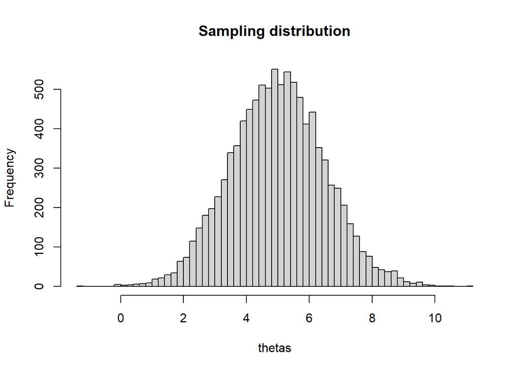

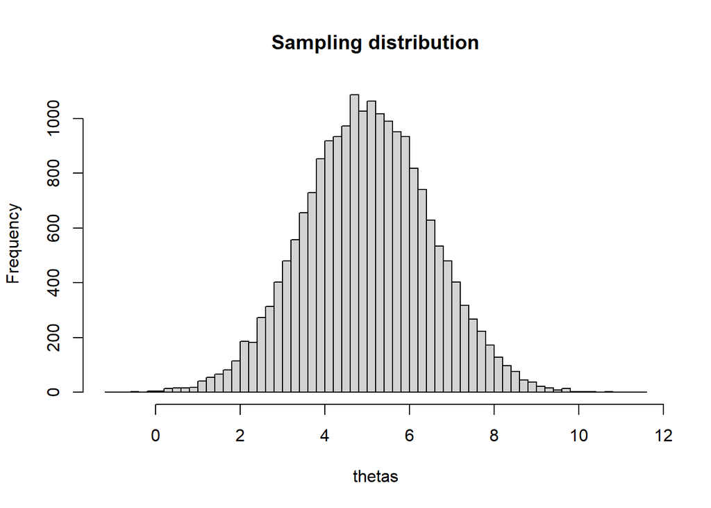

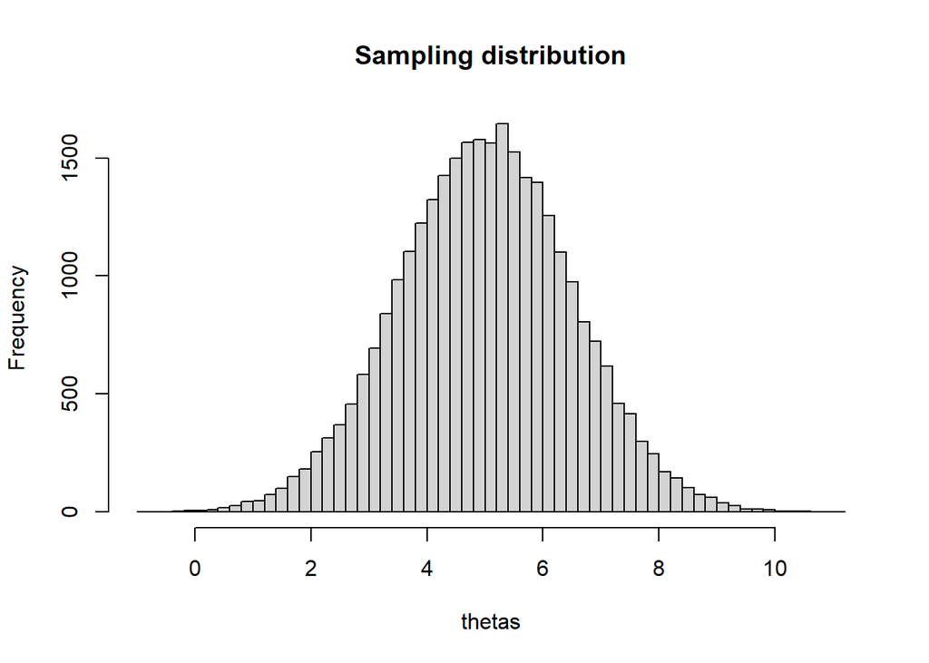

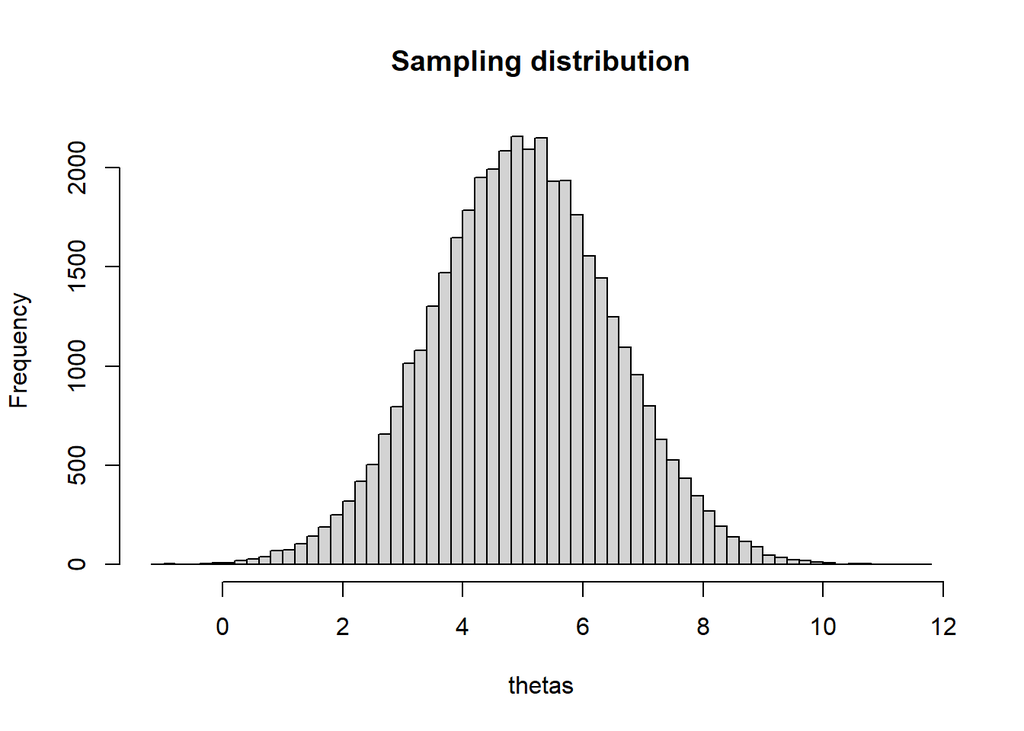

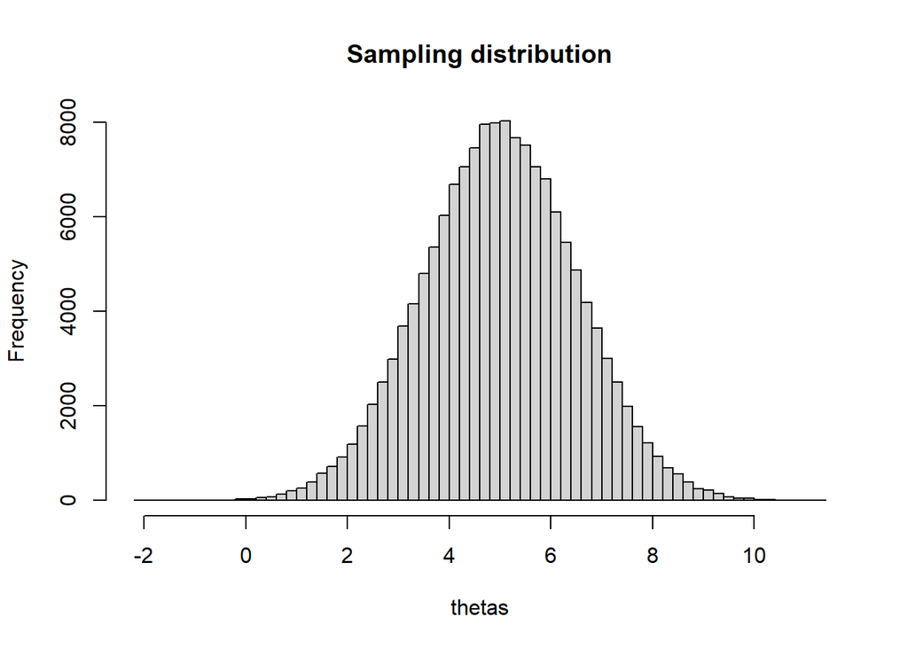

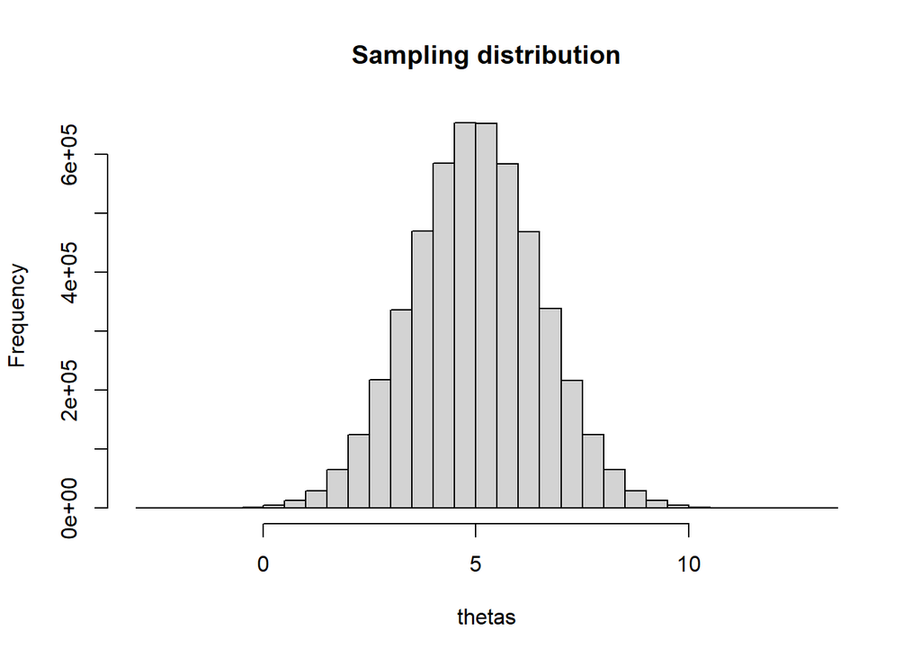

```r
X <- 10000
 sizes <- c(1, 2, 3, 4, 15, 500)
 mean <- 5
 sd <- 1.5

 for(n in sizes){
   thetas <- replicate(X, {
     samp <- rnorm(n, mean, sd)
     #disc_samp(n)
   })
   hist(thetas, breaks = 50,
        main = "Sampling distribution", axes= TRUE)
   }
```